# S&P 500 Stock Market Predictions and Analyses

# Primary Analysis

Based on our primary question: "Can we accurately predict future stock prices based on historical data?" A regression analysis would be the most suitable. Regressions are designed for scenarios just like this where predictions are needed to be made. Taking in past trends and data a regression model can help us make informative decisions for the future. The regression machine learning technique can take in many variables from our data that will be needed to make predictions. Many variables in economics such as stock price, volume, and other factors are crucial so the machine can make more accurate decisions. More on regression: https://builtin.com/data-science/regression-machine-learning#:~:text=Regression%20in%20machine%20learning%20consists,use%20in%20predicting%20and%20forecasting.

# Preparing the Data

```python
cleaned_stocks_data['date'] = pd.to_datetime(cleaned_stocks_data['date'])
cleaned_stocks_data['year'] = cleaned_stocks_data['date'].dt.year
cleaned_stocks_data['month'] = cleaned_stocks_data['date'].dt.month

# Calculate moving averages and other technical indicators
cleaned_stocks_data['5_day_avg'] = cleaned_stocks_data['close'].rolling(window=5).mean()
cleaned_stocks_data['30_day_avg'] = cleaned_stocks_data['close'].rolling(window=30).mean()
cleaned_stocks_data['5_day_volatility'] = cleaned_stocks_data['daily_return'].rolling(window=5).std()
cleaned_stocks_data['5_to_30_day_avg_ratio'] = cleaned_stocks_data['5_day_avg'] / cleaned_stocks_data['30_day_avg']

cleaned_stocks_data['prev_close'] = cleaned_stocks_data['close'].shift(1)
cleaned_stocks_data['prev_return'] = cleaned_stocks_data['daily_return'].shift(1)

cleaned_stocks_data.dropna(inplace=True)
```

First, we're converting the 'date' column to a proper datetime format, which allows us to easily extract the year and month from each date. This gives us a better sense of when each data point occurs.

Next, we're calculating some technical indicators that traders often use. We're creating a 5-day and a 30-day moving average of the closing prices, which helps us see short-term and longer-term trends. We're also calculating the 5-day volatility to understand how much the stock price has been fluctuating recently. We then create a ratio between the 5-day and 30-day averages, which can indicate potential changes in trend.

We're also looking at how the stock performed yesterday by adding columns for the previous day's closing price and return. This helps us understand how today's performance relates to yesterday's.

Finally, we're cleaning up our data by removing any rows that have missing values. This ensures that all our data is complete and ready for analysis.

```python
# Feature and target array
X = cleaned_stocks_data[['prev_close', '5_day_avg', '30_day_avg', '5_day_volatility', '5_to_30_day_avg_ratio', 'prev_return']].values
y = cleaned_stocks_data['close'].values.reshape(-1, 1)

# Splitting the data
X_train, X_test, y_train, y_test = train_test_split(X, y, test_size=0.2, random_state=42)

# Scaling the features
scaler_x = StandardScaler()
X_train_scaled = scaler_x.fit_transform(X_train)
X_test_scaled = scaler_x.transform(X_test)

scaler_y = StandardScaler()
y_train_scaled = scaler_y.fit_transform(y_train)
y_test_scaled = scaler_y.transform(y_test)
```

We're now preparing our data for the neural network. First, we're selecting the features we want to use to make our predictions. These include things like the previous day's closing price, moving averages, volatility, and other indicators we calculated earlier. We're also identifying our target variable, which is the closing price we want to predict.

Next, we're splitting our data into two parts: a training set and a test set. We'll use the training set to teach our model, and the test set to check how well it's learned. We're using 80% of our data for training and keeping 20% for testing.

After that, we're scaling our data. We're doing this separately for our features (X) and our target variable (y). We're careful to fit our scaler only on the training data and then apply it to both training and test data. This prevents any information from the test set from leaking into our training process.

# Building the Neural Network

```python
# Building the model
model = tf.keras.Sequential([
    tf.keras.layers.Dense(64, activation='relu', input_shape=(X_train_scaled.shape[1],)),
    tf.keras.layers.Dense(32, activation='relu'),
    tf.keras.layers.Dense(1)
])

# Compiling the model
model.compile(optimizer='adam', loss='mean_squared_error')
```

We're using three layers: our first layer takes in all our data and has 64 neurons to process it. Then we have a middle layer with 32 neurons to further refine the information. Finally, we have an output layer with just one neuron to give us our prediction. We're using ReLU activation in our first two layers. More info on ReLU: https://machinelearningmastery.com/rectified-linear-activation-function-for-deep-learning-neural-networks/

We're using an optimization method called Adam, which is really good at helping the model improve quickly. We're also telling it that its goal is to minimize the mean squared error. This means we want our model's predictions to be as close as possible to the actual values in our training data. By setting it up this way, we're preparing our model to make accurate numerical predictions based on the input data we'll give it.

# Training the Model

```python
history = model.fit(X_train_scaled, y_train_scaled, epochs=25, batch_size=32, validation_split=0.2, verbose=1)
```

[output not shown]

# Analysis of Training Performance:

-Final Epochs Improvement: By the last epoch, both training and validation losses have decreased significantly compared to the initial epochs. The final values suggest that the model has trained well.

# Evaluating the Model

```
Test loss (MSE): 0.0005603833124041557
```

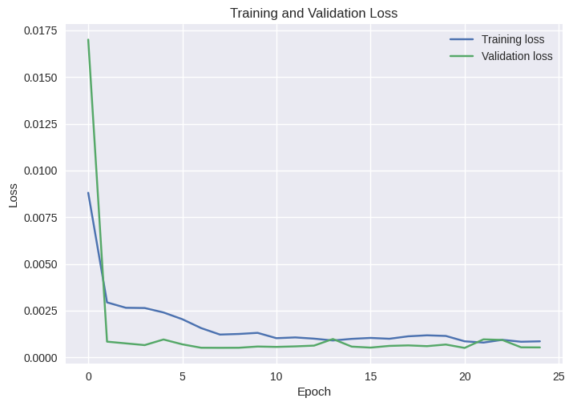

```python
# Evaluate the model on test data
test_loss = model.evaluate(X_test_scaled, y_test_scaled, verbose=0)
print('Test loss (MSE):', test_loss)

# Plotting training history
plt.plot(history.history['loss'], label='Training loss')
plt.plot(history.history['val_loss'], label='Validation loss')
plt.title('Training and Validation Loss')
plt.xlabel('Epoch')
plt.ylabel('Loss')
plt.legend()
plt.show()
```

# Key Observations:

-Test Loss (MSE):

The MSE is very low (0.0005603833124041557). This indicates excellent performance from the model. More on MSE: https://builtin.com/machine-learning/loss-functions

-Training Loss:

This line represents the loss of the neural network on the training dataset over epochs. The training loss generally decreases as the network learns from the data, optimizing its weights to minimize prediction errors. The trend shows a general decrease, and shows the model is effectively learning from the training data.

# Making Predictions

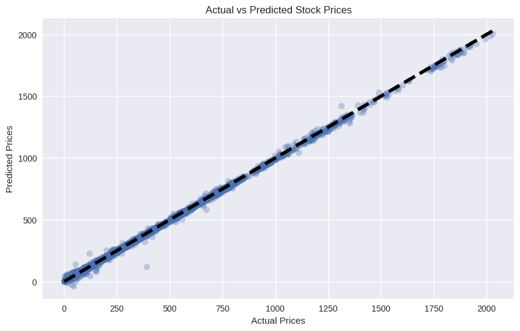

```python
# Making predictions
predictions_scaled = model.predict(X_test_scaled)
predictions = scaler_y.inverse_transform(predictions_scaled)

# Plot predicted vs actual prices
plt.figure(figsize=(10, 6))
plt.scatter(y_test, predictions, alpha=0.3)
plt.xlabel('Actual Prices')
plt.ylabel('Predicted Prices')
plt.plot([y_test.min(), y_test.max()], [y_test.min(), y_test.max()], 'k--', lw=4)
plt.title('Actual vs Predicted Stock Prices')
plt.show()
```

# Analysis of Predictions Plot:

-General Trend: The data points cluster around the diagonal line, indicating that the model's predictions are generally close to the actual prices. This means that the model is accurate in terms of its predictive capabilities.

-Model Effectiveness: The closeness of most data points to the diagonal line suggests that the model is effective in predicting stock prices across different ranges, though it may perform better at lower price ranges.

# Insights and Conclusions

## Project Overview:

This project aimed to understand historical S&P 500 data to predict future stock prices and analyze sector performance. This initiative not only targeted enhancements in investment strategies through predictive analytics but also sought to deepen the understanding of sector dynamics within the index.

## Understandings:

For Uninformed Readers: The project systematically explains the relevance of the S&P 500, details the machine learning approaches used, and explores the findings in a way that teaches readers the fundamentals of stock market analytics. Uninformed readers obtain a basic understanding of how data science can forecast stock market movements and the elements that affect sector success.

For Informed Readers: Even those familiar with financial analytics would find the detailed examination of sector-specific performances enlightening. The application of various statistical tests (Chi-Squared, Z-Tests, ANOVA) to real-world data offers insights into the practical challenges and complexities of predicting stock prices and sector behaviors.

## Statistical Analysis:

### ANOVA:

The lack of significant differences among sectorial daily returns suggests that external factors might play a larger role in influencing stock prices than previously considered.

## Implications for Stakeholders:

### Investors:

Insights from this project can guide portfolio diversification strategies, especially in understanding sector-specific risks and returns. More info on this: https://www.spglobal.com/spdji/en/documents/research/research-the-impact-of-the-global-economy-on-the-sp-500.pdf

### Policy Makers and Economists:

Understanding sector dynamics can aid in making economic policies that enhance the stability and growth of important market segments.

### Data Scientists:

The project underscores the importance of robust data preprocessing and the potential of machine learning in financial predictions.

## Conclusions:

The analysis effectively shows the use of data science in finance, offering significant insights on stock price predictability and sector performance within the S&P 500. While it lays a solid framework for forecasting and sector analysis, it also emphasizes the constraints brought on by external economic forces and market fluctuations. Future research might focus on strengthening predictive models and investigating deeper inter-sectoral aspects to improve prediction accuracy.

# Overall Experience:

Both uninformed and informed readers are likely to find the project's approach comprehensive and its conclusions insightful. It effectively bridges the gap between theoretical data science applications and practical financial market analytics, enriching the reader's understanding of both areas.

```python
%%shell
jupyter nbconvert --to html ///content/Checkpoint2-7.ipynb
```

```
[NbConvertApp] Converting notebook ///content/Checkpoint2-7.ipynb to html
[NbConvertApp] Writing 1045978 bytes to /content/Checkpoint2-7.html
```